# R Notebook

# Analisando commits do github de 2016/2017

Nesta análise iremos explorar e analisar uma *amostra* de dados sobre commits no github realizados nos anos de 2016 e 2017. Os dados contem as seguintes variáveis:

*file_extension*: Extensão do arquivo que foi feito commit.  
*month_day*: Dia do mês em que foi feito o commit.  
*the_month*: Mês no qual foi realizado o commit.  
*the_year*: Ano no qual foi realizado o commit.  
*users*: Quantidade de usuários que realizaram commits com a extensão em questão no dia especificado.

Logo abaixo temos a leitura/filtragem dos dados e importação de bibliotecas que utilizarei nessa análise.

```r
library('tidyverse')
library('chron')
library('resample')
library('ggplot2')
library('boot')
library('scales')

dados = read_csv('github-users-committing-filetypes.csv')

dados <- dados %>% mutate(data = sprintf("%d-%d-%d", the_year, the_month, month_day)) %>% filter(complete.cases(dados))
```

Com base nessas variáveis iremos escolher duas linguagens (*JavaScript* e *Go*) e responder duas perguntas sobre elas. A primeira pergunta é:

## Pergunta 1: Para cada uma delas, há uma diferença significativa na sua popularidade durante a semana e durante o fim de semana? Essa diferença é grande?

Para obter a resposta para esse primeira pergunta seguiremos os seguintes passos:

### 1: Filtrar os dados para as duas linguagens escolhidas

Abaixo temos a filtragem para as duas linguagens escolhidas e temos ainda a adição de uma coluna auxiliar que nos informa se um dia é um final de semana ou não.

```r
amostra_go = dados %>% filter(file_extension == 'go') %>% mutate(is_weekend = is.weekend(data))
amostra_js = dados %>% filter(file_extension == 'js') %>% mutate(is_weekend = is.weekend(data))
```

### 2: Criar uma estatística customizada que viabilize calcular a popularidade de cada linguagem

A estratégia utilizada foi a de calcular a proporção entre a média de usúarios que fazem commit naquela linguagem durante a semana e a média de usuários que fazem commit naquela linguagem durante o final de semana. Esta abordagem é interessante pois o valor da estatística em si já se torna bastante significativo. Se for maior do que *1* temos uma média de commits maior durante a semana, caso contrário a média de commits é maior durante o final de semana.

```r
pop <- function(x,i){
  d = x[i,]
  mean_week = d %>% filter(!is_weekend) %>% summarise(media = mean(users))
  mean_weekend = d %>% filter(is_weekend) %>% summarise(media = mean(users))
  return(mean_week$media/mean_weekend$media)
}
```

### 3: Reamostrar a amostra utilizando bootstraping e gerar um intervalo de confiança para a estatística criada

Esse passo é necessário para que a a distribuição amostral que estamos utilizando reflita mais fortemente a população como um todo, permitindo assim que possamos inferir dados sobre a população. Neste caso foram realizadas *5 mil* reamostragens a partir da amostra original.

```r
b_pop_go = bootstrap(amostra_go, pop, 5000)
popularity_go = CI.bca(b_pop_go, c = probs(.025, .975))
popularity_go
```

```
        2.5%    97.5%
pop 1.677932 1.748292
```

Já para a linguagem *JavaScript* o intervalo obtido foi o seguinte:

```r
b_pop_js = bootstrap(amostra_js, pop, 5000)
popularity_js = CI.bca(b_pop_js, c = probs(.025, .975))
popularity_js
```

```
        2.5%    97.5%
pop 1.627675 1.727955
```

Uma breve visualização para ajudar a entender a relevância dos resultados obtidos. A linha laranja representa o ponto que separa as *linguagens de fim de semana* das *linguagens de semana*.

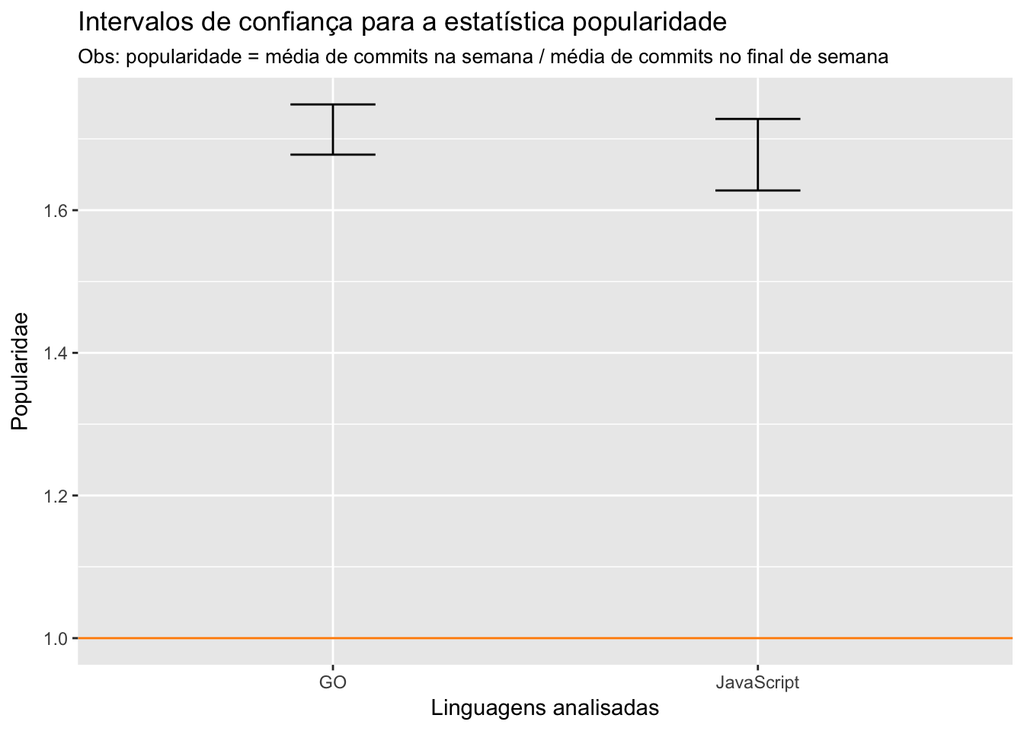

```r
df = data.frame(rbind(popularity_go, popularity_js))
df$medida = rownames(df)
df %>%
  ggplot(aes(x = c("GO", "JavaScript"), ymin = X2.5., ymax = X97.5.)) +
  geom_errorbar(width = .2) +
  geom_hline(yintercept = 1, colour = "darkorange") +
  labs(title = "Intervalos de confiança para a estatística popularidade", x = "Linguagens analisadas", y = "Popularidae", subtitle = "Obs: popularidade = média de commits na semana / média de commits no final de semana")
```

A visualização acima deixa bem claro que séria necessária uma catástrofe estatística para que as linguagens analisadas fossem mais populares no final de semana. Rs.

A segunda pergunta que iremos responder é a seguinte:

## Pergunta 2: Existe uma diferença significativa entre as duas linguagens na sua variação de popularidade nos finais de semana?

A abordagem que vamos utilizar para responder é a mesma utilizada na pergunta 1, com a diferença de que agora utilizaremos como estatística uma *medida de dispersão* o desvio padrão do número de usúarios que realizaram commits considerando *apenas* os fins de semana.

```r
desvio_fds <- function(x, i){

  d = x[i,]
  d_sd = d %>% filter(is_weekend)
  return(sd(d_sd$users))
}
```

Agora realizando o bootstraping e calculando o intervalo de confiança para a linguagem *JavaScript*:

```r
b_sd_js = bootstrap(amostra_js, desvio_fds, 5000)
variation_js = CI.bca(b_sd_js, c = probs(.025, .975))
variation_js
```

```
               2.5%    97.5%
desvio_fds 565.2688 760.2623
```

A primeira vista é difiícil dizer se este é um desvio padrão alto ou baixo, vamos gerar um intervalo de confiança para a média para ter uma noção melhor:

```r
b_mean_js = bootstrap(amostra_js, mean(users), 5000)
mean_js = CI.bca(b_mean_js, c = probs(.025, .975))
mean_js
```

```
                2.5%    97.5%
mean(users) 6080.331 6361.874
```

Pelo intervalo gerado para a média, percebemos que o desvio padrão obtido para a linguagem *JavaScript* é de aproximadamente *10%* da média, ou seja com *95%* de significância podemos afirmar que temos uma variação de apenas *10%* na quantidade de commits nos finais de semana em geral. Valor que não é muito alto, portanto *Não existe uma diferença significativa na variação de popularidade de JavaScript nos finais de semana.*

Para *Go* vamos seguir a mesma lógica:

```r
b_sd_go = bootstrap(amostra_go, desvio_fds, 5000)
variation_go = CI.bca(b_sd_go, c = probs(.025, .975))
variation_go
```

```
               2.5%    97.5%
desvio_fds 40.65001 53.35722
```

Agora calculando um intevalo de confiança para a média:

```r
b_mean_go = bootstrap(amostra_go, mean(users), 5000)
mean_go = CI.bca(b_mean_go, c = probs(.025, .975))
mean_go
```

```
                2.5%    97.5%
mean(users) 870.7148 906.6521
```

Para a linguagem *Go* temos nos finais de semana uma variação de popularidade em torno de *5%* da média de commits realizados. Variação ainda menor do que a linguagem anterior, portanto *Não existe uma diferença significativa na popularidade de Go nos finais de semana.*